# Predicting Player Spending Behavior and Profitability in Mobile Games

### 7.3 Individual Player Explanation (Waterfall Plot)

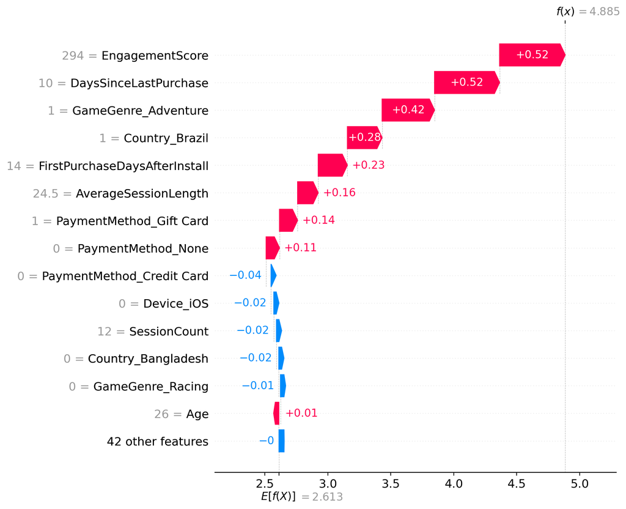

Figure 18: SHAP waterfall plot for a representative high-spending player (row 2000)

```python
row_idx = 2000
shap.plots.waterfall(shap_values[row_idx], max_display=15, show=True)
```

**Interpretation (Figure 18):** The waterfall plot traces the prediction for a single representative player, showing how each feature pushes the prediction above or below the baseline (the average log-spending). For high-spending players, short `DaysSinceLastPurchase`, high `EngagementScore`, long `AverageSessionLength`, and having a valid payment method all contribute positively. The pattern confirms that the model identifies high spenders primarily through recent activity, strong engagement, and payment readiness.

### 7.4 Multi-Player Decision Paths (SHAP Decision Plot)

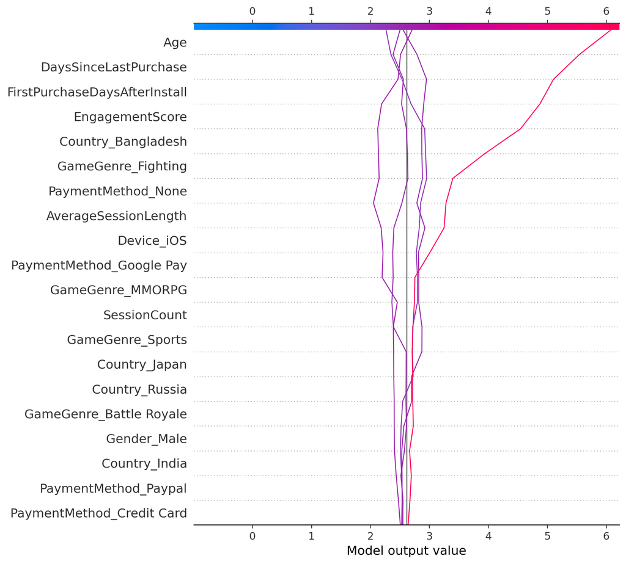

Figure 19: SHAP decision plot tracing predictions for 5 representative players

```python
idx_list = [1, 2, 3, 4, 5]
shap.decision_plot(
    base_value   = explainer.expected_value,
    shap_values  = shap_values.values[idx_list, :],
    features     = X_train.iloc[idx_list, :],
    feature_names= X_train.columns.tolist(),
    show         = True
)
```

**Interpretation (Figure 19):** The decision plot traces SHAP trajectories across several players simultaneously. Higher-spending players accumulate positive contributions through low recency, early first-purchase timing, stronger engagement, and having a specified payment method. Lower-spending players show the opposite pattern: long inactivity, `PaymentMethod_None`, and lower engagement pull predictions downward. The consistent alignment of these trajectories confirms that the model has learned a stable decision structure based on behavioral readiness and payment availability.

### 7.5 Population-Level SHAP Heatmap

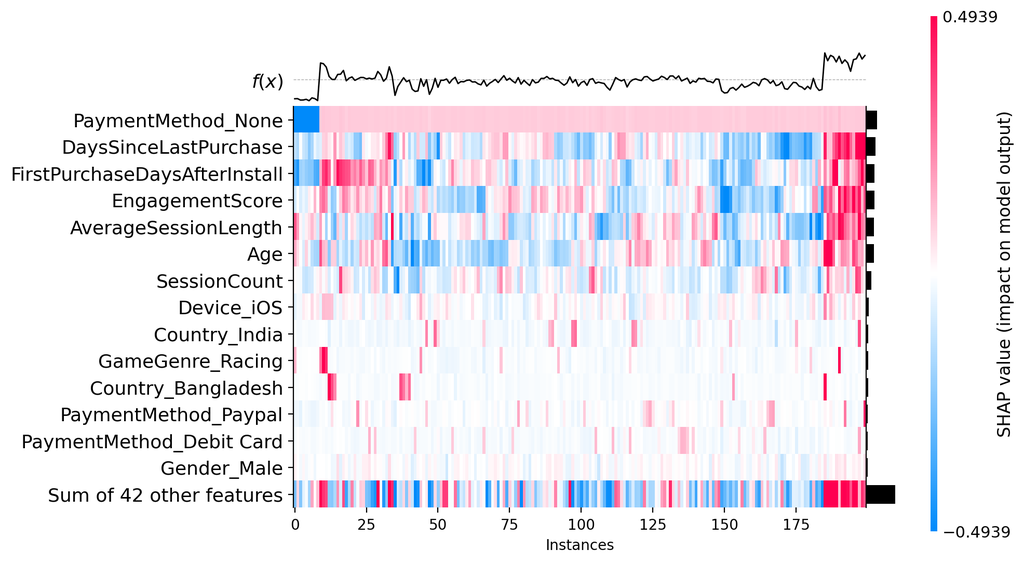

Figure 20: SHAP heatmap for 200 training players (top features shown)

```python
shap.plots.heatmap(shap_values[:200], max_display=15, show=True)
```

**Interpretation (Figure 20):** The SHAP heatmap visualizes feature contributions for 200 players simultaneously. Distinct horizontal bands for `PaymentMethod_None`, `DaysSinceLastPurchase`, `EngagementScore`, and `AverageSessionLength` show clear and consistent red/blue contrasts across players. Most other features display faint patterns near zero. The systematic structure across many players shows that, despite the limited overall R², the XGBoost model has learned a stable and interpretable rule: **players who are recently active, highly engaged, and have a valid payment method are predicted to spend more**.

## 8. Model Comparison

```python
results = pd.DataFrame({
    "Model":  ["Linear Regression", "Lasso Regression", "Decision Tree",
               "Random Forest",     "XGBoost"],
    "MAE":    [lr_mae,    lasso_mae, dt_mae,    rf_mae,    xgb_mae],
    "RMSE":   [lr_rmse,   lasso_rmse, dt_rmse,  rf_rmse,   xgb_rmse],
    "R²":     [lr_r2,     lasso_r2,  dt_r2,     rf_r2,     xgb_r2]
}).sort_values("R²", ascending=False).reset_index(drop=True)

results["MAE"]  = results["MAE"].round(4)
results["RMSE"] = results["RMSE"].round(4)
results["R²"]   = results["R²"].round(4)

print("Table 1: Regression Model Performance on Test Set\n")
display(results)
```

```
Table 1: Regression Model Performance on Test Set
```

|  | Model | MAE | RMSE | R² |
| --- | --- | --- | --- | --- |
| 0 | Lasso Regression | 0.9309 | 1.4133 | 0.1004 |
| 1 | Decision Tree | 0.9377 | 1.4335 | 0.0745 |
| 2 | Linear Regression | 0.9751 | 1.4504 | 0.0525 |
| 3 | Random Forest | 1.0100 | 1.4576 | 0.0431 |
| 4 | XGBoost | 1.1533 | 1.5832 | -0.1288 |

The overall conclusion is that predicting individual spending amounts with this feature set is not feasible with high accuracy. However, the consistent feature rankings across all models — payment readiness, recency, and engagement — provide actionable behavioral insights even when predictive accuracy is limited.

## 9. Classification: Identifying Whale Users

Since spending is highly concentrated among a small group of “whale” users, early identification of these high-value players holds significant strategic importance for game studios. This section trains a logistic regression classifier to distinguish whales (top 5% of spenders) from all other players.

### 9.1 Define Whale Label and Prepare Features

```python
# Define whale = top 5% of spenders
threshold = df['InAppPurchaseAmount'].quantile(0.95)
df['Whale'] = (df['InAppPurchaseAmount'] >= threshold).astype(int)

print(f"Whale threshold (95th percentile): ${threshold:.2f}")
print(f"Whale users: {df['Whale'].sum()} ({df['Whale'].mean()*100:.1f}% of all players)")

# Classification feature matrix
df_cls = df.drop(columns=['Cluster', 'ClusterLabel'], errors='ignore')
X_cls = df_cls.drop(
    columns=['Whale', 'InAppPurchaseAmount', 'log_spend', 'AvgSpendPerSession', 'SpendingSegment'],
    errors='ignore'
)
X_cls = X_cls.select_dtypes(include=[np.number])
y_cls = df_cls['Whale']

X_train_cls, X_test_cls, y_train_cls, y_test_cls = train_test_split(
    X_cls, y_cls, test_size=0.2, random_state=42, stratify=y_cls
)

print(f"\nClassification training set: {X_train_cls.shape[0]} samples "
      f"| Test set: {X_test_cls.shape[0]} samples")
```

```
Whale threshold (95th percentile): $361.10
Whale users: 137 (5.0% of all players)

Classification training set: 2186 samples | Test set: 547 samples
```

### 9.2 Logistic Regression Classifier

```python
log_reg = LogisticRegression(max_iter=500, class_weight='balanced')
log_reg.fit(X_train_cls, y_train_cls)

y_pred_cls = log_reg.predict(X_test_cls)
y_prob_cls = log_reg.predict_proba(X_test_cls)[:, 1]

print(f"Accuracy: {accuracy_score(y_test_cls, y_pred_cls):.4f}")
print(f"\nClassification Report:\n{classification_report(y_test_cls, y_pred_cls, target_names=['Non-Whale', 'Whale'])}")
```

```
Accuracy: 0.6033

Classification Report:
              precision    recall  f1-score   support

   Non-Whale       0.96      0.61      0.74       520
       Whale       0.07      0.56      0.12        27

    accuracy                           0.60       547
   macro avg       0.52      0.58      0.43       547
weighted avg       0.92      0.60      0.71       547
```

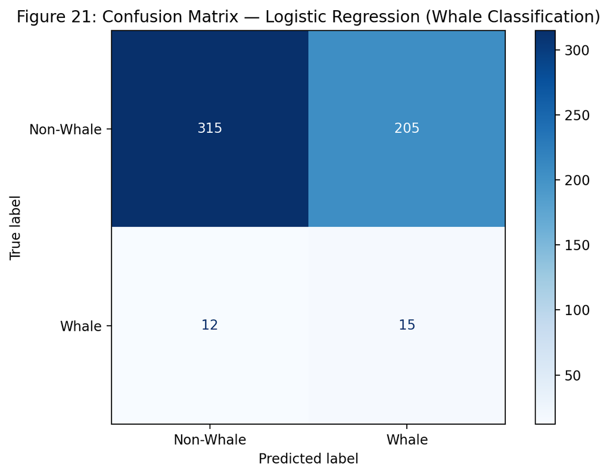

Figure 21: Confusion matrix — logistic regression whale classifier

```python
cm = confusion_matrix(y_test_cls, (y_prob_cls >= 0.5).astype(int))
disp = ConfusionMatrixDisplay(confusion_matrix=cm, display_labels=["Non-Whale", "Whale"])
disp.plot(cmap="Blues")
plt.title("Figure 21: Confusion Matrix — Logistic Regression (Whale Classification)")
plt.tight_layout()
plt.show()
```

### 9.3 ROC Curve and AUC

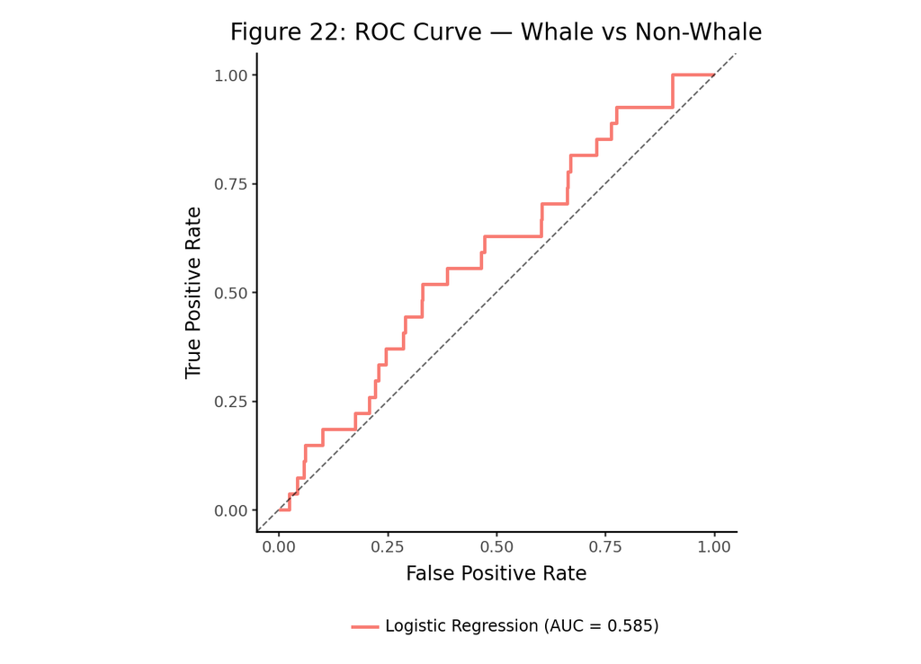

Figure 22: ROC curve for the whale vs non-whale classifier

```python
fpr, tpr, _ = roc_curve(y_test_cls, y_prob_cls)
auc_val = roc_auc_score(y_test_cls, y_prob_cls)

df_roc = pd.DataFrame({"fpr": fpr, "tpr": tpr})
df_roc["Label"] = f"Logistic Regression (AUC = {auc_val:.3f})"

p_roc = (
    ggplot(df_roc, aes(x="fpr", y="tpr", color="Label"))
    + geom_line(size=1.05, alpha=0.95)
    + geom_abline(intercept=0, slope=1, linetype="dashed", alpha=0.6)
    + coord_equal()
    + theme_classic()
    + theme(legend_position="bottom",
            legend_title=element_text(size=9),
            legend_text=element_text(size=9))
    + labs(title="Figure 22: ROC Curve — Whale vs Non-Whale",
           x="False Positive Rate", y="True Positive Rate", color="")
)
display(p_roc.draw()); plt.close('all')
```

This result is not unexpected. Several factors contribute to the poor discrimination:

1. **Feature overlap**: Whale and non-whale players share similar behavioral profiles in this dataset.
2. **Linear boundary**: Logistic regression cannot capture the complex, nonlinear boundaries that likely separate these groups.
3. **Missing signals**: Early whale identification likely requires richer features such as purchase frequency sequences, shop visit history, and offer interactions — which are not present in this dataset.
4. **Synthetic data**: The dataset may not fully capture the pronounced early behavioral differences between high-value users and the general population that are observable in real games.

These findings highlight that **identifying high-value players early is significantly harder than predicting general spending trends**, and would require substantially richer behavioral data and more flexible classification methods.